# Lab 12 Homework

Itzel Gonzalez

2025-02-25

## Instructions

Answer the following questions and complete the exercises in RMarkdown. Please embed all of your code and push your final work to your repository. Your final lab report should be organized, clean, and run free from errors. Remember, you must remove the `#` for the included code chunks to run. Be sure to add your name to the author header above. For any included plots, make sure they are clearly labeled. You are free to use any plot type that you feel best communicates the results of your analysis.

Make sure to use the formatting conventions of RMarkdown to make your report neat and clean!

## Load the libraries

```r
library(tidyverse)
library(janitor)
library(naniar)
```

```r
options(scipen = 999)
```

## Resources

The idea for this assignment came from [Rebecca Barter’s](http://www.rebeccabarter.com/blog/2017-11-17-ggplot2_tutorial/) ggplot tutorial so if you get stuck this is a good place to have a look.

## Gapminder

For this assignment, we are going to use the dataset [gapminder](https://cran.r-project.org/web/packages/gapminder/index.html). Gapminder includes information about economics, population, and life expectancy from countries all over the world. You will need to install it before use.

```r
#install.packages("gapminder")
library("gapminder")
```

1. Use the function(s) of your choice to get an idea of the overall structure of the data frame, including its dimensions, column names, variable classes, etc. As part of this, determine how NA’s are treated in the data

**There are no NAs.**

```r
summary(gapminder)
```

```
##         country        continent        year         lifeExp
##  Afghanistan:  12   Africa  :624   Min.   :1952   Min.   :23.60
##  Albania    :  12   Americas:300   1st Qu.:1966   1st Qu.:48.20
##  Algeria    :  12   Asia    :396   Median :1980   Median :60.71
##  Angola     :  12   Europe  :360   Mean   :1980   Mean   :59.47
##  Argentina  :  12   Oceania : 24   3rd Qu.:1993   3rd Qu.:70.85
##  Australia  :  12                  Max.   :2007   Max.   :82.60
##  (Other)    :1632
##       pop               gdpPercap
##  Min.   :     60011   Min.   :   241.2
##  1st Qu.:   2793664   1st Qu.:  1202.1
##  Median :   7023596   Median :  3531.8
##  Mean   :  29601212   Mean   :  7215.3
##  3rd Qu.:  19585222   3rd Qu.:  9325.5
##  Max.   :1318683096   Max.   :113523.1
##
```

2. How many countries are represented in this dataset? Make a table and a plot that shows the number of countries by continent.

**There are 142 countries represented in this data set.**

```r
gapminder %>%
  distinct(country) %>%
  count()
```

```
## # A tibble: 1 × 1
##       n
##   <int>
## 1   142
```

```r
gapminder %>%
  group_by(continent) %>%
  summarize(n=n_distinct(country))
```

```
## # A tibble: 5 × 2
##   continent     n
##   <fct>     <int>
## 1 Africa       52
## 2 Americas     25
## 3 Asia         33
## 4 Europe       30
## 5 Oceania       2
```

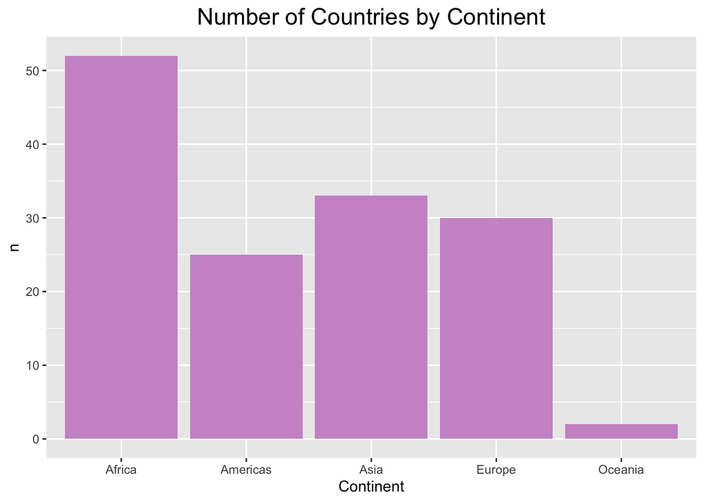

```r
gapminder %>%
  select(country, continent) %>%
  distinct() %>%
  group_by(continent) %>%
  count() %>%
  ggplot(aes(x=continent, y=n))+
  geom_col(fill='plum3')+
  labs(title='Number of Countries by Continent', x='Continent', y='n')+
  theme(plot.title = element_text(size = rel(1.5), hjust = 0.5))
```

3. Which country has the largest population growth since 1952? Show this as a table.

**China has the largest population growth since 1952.**

```r
gapminder %>%
  filter(year %in% c(1952, 2007)) %>%
  select(country, year, pop) %>%
  pivot_wider(names_from = year, values_from = pop)  %>%
  mutate(population_growth = `2007` - `1952`) %>%
  arrange(-population_growth)
```

```
## # A tibble: 142 × 4
##    country          `1952`     `2007` population_growth
##    <fct>             <int>      <int>             <int>
##  1 China         556263527 1318683096         762419569
##  2 India         372000000 1110396331         738396331
##  3 United States 157553000  301139947         143586947
##  4 Indonesia      82052000  223547000         141495000
##  5 Brazil         56602560  190010647         133408087
##  6 Pakistan       41346560  169270617         127924057
##  7 Bangladesh     46886859  150448339         103561480
##  8 Nigeria        33119096  135031164         101912068
##  9 Mexico         30144317  108700891          78556574
## 10 Philippines    22438691   91077287          68638596
## # ℹ 132 more rows
```

4. Make a plot that shows population growth for the country you found in question

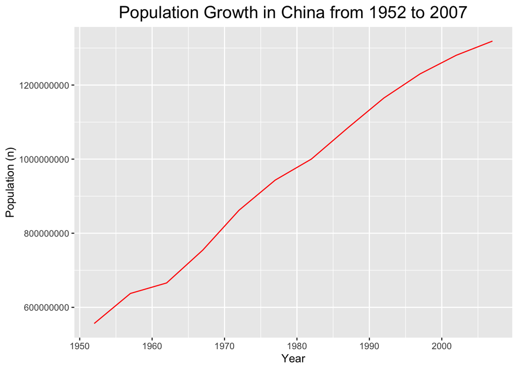

```r
gapminder %>%
  filter(country=='China') %>%
  select(country, year, pop) %>%
  ggplot(aes(x=year, y=pop))+
  geom_line(color='red')+
  labs(title = "Population Growth in China from 1952 to 2007",
       x = "Year",
       y = "Population (n)")+
  theme(plot.title = element_text(size = rel(1.5), hjust = 0.5))
```

5. How has global life expectancy changed between 1952 and 2007? Show the min, mean, and max for all countries in the dataset. Show this as a table.

```r
gapminder %>%
  select(country, year, lifeExp) %>%
  group_by(country) %>%
  summarize(min_lifexp=min(lifeExp, na.rm = TRUE),
            mean_lifeExp=mean(lifeExp, na.rm = TRUE),
            max_lifeExp=max(lifeExp, na.rm = TRUE))
```

```
## # A tibble: 142 × 4
##    country     min_lifexp mean_lifeExp max_lifeExp
##    <fct>            <dbl>        <dbl>       <dbl>
##  1 Afghanistan       28.8         37.5        43.8
##  2 Albania           55.2         68.4        76.4
##  3 Algeria           43.1         59.0        72.3
##  4 Angola            30.0         37.9        42.7
##  5 Argentina         62.5         69.1        75.3
##  6 Australia         69.1         74.7        81.2
##  7 Austria           66.8         73.1        79.8
##  8 Bahrain           50.9         65.6        75.6
##  9 Bangladesh        37.5         49.8        64.1
## 10 Belgium           68           73.6        79.4
## # ℹ 132 more rows
```

6. Make a plot that shows how mean life expectancy has changed over time for each continent. What is your interpretation of what happened in Africa between 1987 and 2002?

**My interpretation of what happened in Africa between 1987 and 2002 could be that there is a disease outbreak which could have led to a higher mortality rate. Additionally, if this was the case, limited access to health care can also contribute to the plataeu line.**

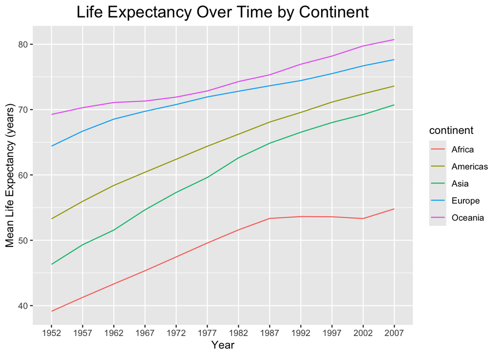

```r
gapminder %>%
  group_by(continent, year) %>%
  summarize(mean_lifeExp = mean(lifeExp, na.rm = TRUE), .groups='drop') %>%
  ggplot(aes(x=as.factor(year), y=mean_lifeExp, color= continent, group = continent))+
  geom_line()+
  labs(title = "Life Expectancy Over Time by Continent",
       x = "Year",
       y = "Mean Life Expectancy (years)")+
  theme(plot.title = element_text(size = rel(1.5), hjust = 0.5))
```

7. We are interested in the relationship between per capita GDP and life expectancy; i.e. does having more money help you live longer? Show this as a plot.

**According to the plot, having more money helps you live longer.**

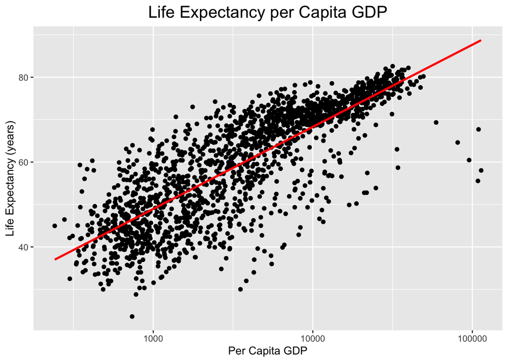

```r
gapminder %>%
  ggplot(aes(x=gdpPercap, y=lifeExp))+
  geom_point()+ scale_x_log10()+
  geom_smooth(method=lm, se=F, color='red')+
  labs(title = 'Life Expectancy per Capita GDP', x='Per Capita GDP', y='Life Expectancy (years)')+
  theme(plot.title = element_text(size = rel(1.5), hjust = 0.5))
```

8. Which five countries have had the highest GDP per capita growth over the years represented in this dataset? Show this as a table.

**The five countries that have the highest GDP per capita over the years include: Singapore, Norway, Hong Kong,China, Ireland, and Austria.**

```r
gapminder %>%
  filter(year %in% c(1952, 2007)) %>%
  select(country, year, gdpPercap) %>%
  pivot_wider(names_from = year, values_from = gdpPercap)  %>%
  mutate(gdpPercap_growth = `2007` - `1952`) %>%
  arrange(-gdpPercap_growth)
```

```
## # A tibble: 142 × 4
##    country          `1952` `2007` gdpPercap_growth
##    <fct>             <dbl>  <dbl>            <dbl>
##  1 Singapore         2315. 47143.           44828.
##  2 Norway           10095. 49357.           39262.
##  3 Hong Kong, China  3054. 39725.           36671.
##  4 Ireland           5210. 40676.           35466.
##  5 Austria           6137. 36126.           29989.
##  6 United States    13990. 42952.           28961.
##  7 Iceland           7268. 36181.           28913.
##  8 Japan             3217. 31656.           28439.
##  9 Netherlands       8942. 36798.           27856.
## 10 Taiwan            1207. 28718.           27511.
## # ℹ 132 more rows
```

9. How does per capita GDP growth compare between these same five countries? Show this as a plot.

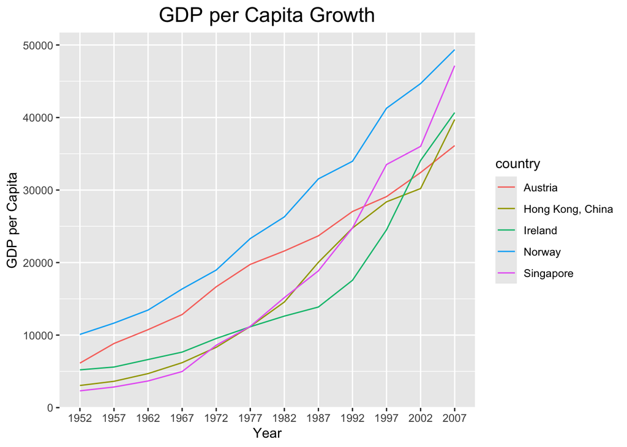

```r
gapminder %>%
  filter(country=="Singapore" | country=="Norway" | country=="Hong Kong, China" | country=="Ireland" | country=="Austria") %>%
  select(year, country, gdpPercap) %>%
  ggplot(aes(x=as.factor(year), y=gdpPercap, group=country, color=country))+
  geom_line()+
  labs(title = "GDP per Capita Growth",
       x = "Year",
       y = "GDP per Capita")+
  theme(plot.title = element_text(size = rel(1.5), hjust = 0.5))
```

10. Do one analysis of your choice that includes a table and plot as outputs.

**How does gdp per capita in North American countries compare to a few European countries over the years?**

```r
gapminder %>%
  filter(continent %in% c('Americas', 'Europe')) %>%
  filter(country %in% c('United States','Mexico', 'Canada', 'Spain', 'Germany', 'Switzerland')) %>%
  select(country, continent, year, gdpPercap) %>%
  pivot_wider(names_from = year, values_from = gdpPercap) %>%
  arrange(continent)
```

```
## # A tibble: 6 × 14
##   country      continent `1952` `1957` `1962` `1967` `1972` `1977` `1982` `1987`
##   <fct>        <fct>      <dbl>  <dbl>  <dbl>  <dbl>  <dbl>  <dbl>  <dbl>  <dbl>
## 1 Canada       Americas  11367. 12490. 13462. 16077. 18971. 22091. 22899. 26627.
## 2 Mexico       Americas   3478.  4132.  4582.  5755.  6809.  7675.  9611.  8688.
## 3 United Stat… Americas  13990. 14847. 16173. 19530. 21806. 24073. 25010. 29884.
## 4 Germany      Europe     7144. 10188. 12902. 14746. 18016. 20513. 22032. 24639.
## 5 Spain        Europe     3834.  4565.  5694.  7994. 10639. 13237. 13926. 15765.
## 6 Switzerland  Europe    14734. 17909. 20431. 22966. 27195. 26982. 28398. 30282.
## # ℹ 4 more variables: `1992` <dbl>, `1997` <dbl>, `2002` <dbl>, `2007` <dbl>
```

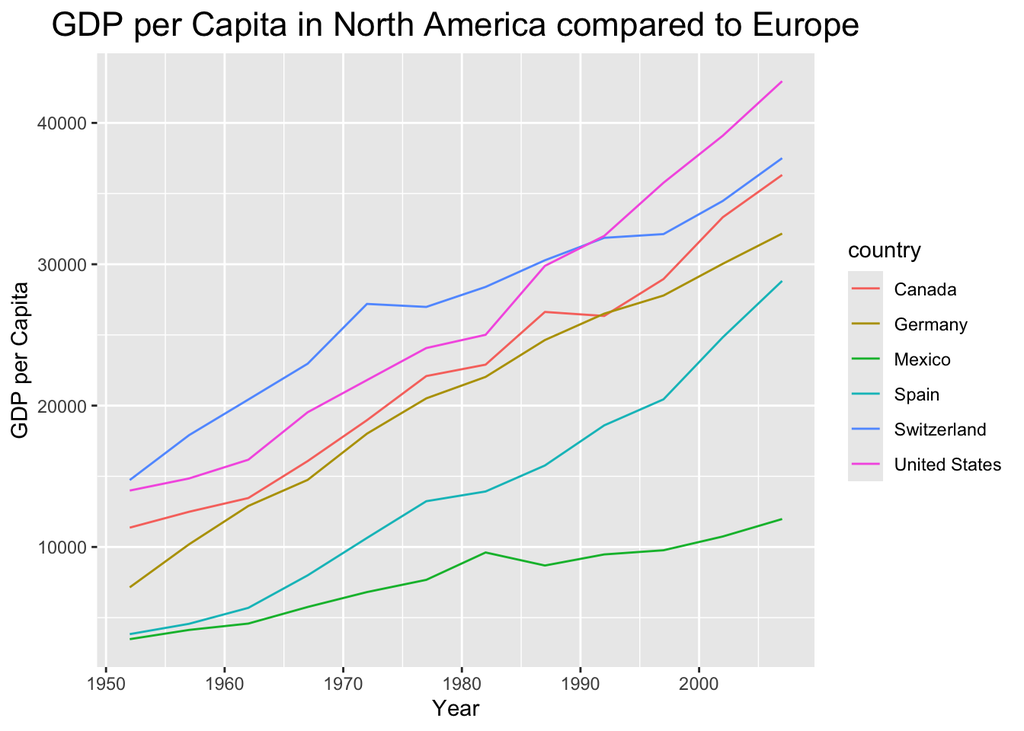

```r
gapminder %>%
  filter(continent %in% c('Americas', 'Europe')) %>%
  filter(country %in% c('United States','Mexico', 'Canada', 'Spain', 'Germany', 'Switzerland')) %>%
  ggplot(aes(x=year, y=gdpPercap, color=country))+
  geom_line()+
  labs(title = "GDP per Capita in North America compared to Europe",
       x = "Year",
       y = "GDP per Capita")+
  theme(plot.title = element_text(size = rel(1.5), hjust = 0.5))
```

## Knit and Upload

Please knit your work as a .pdf or .html file and upload to Canvas. Homework is due before the start of the next lab. No late work is accepted. Make sure to use the formatting conventions of RMarkdown to make your report neat and clean!